# Eighth meeting notes

Daniel L.

4/08/2022

## To prepare for this analysis:

- Step 1: Order of differencing
  - TS plot of residuals from ARIMA(0,0,0) w/ constant in not exactly stationary -> d = 1
- Step 2: AR() or MA()
1. Obtain residual from current model: ARIMA(0,1,0) w/ constant
2. Plot PACF of the residual
- Step 3: Seasonality()
1. Look at the PACF to determine AR() or MA() terms

## Creating models with zoo() and the arima package from stats()

Here we create the ts and create the autoplot of the ts using the zoo package

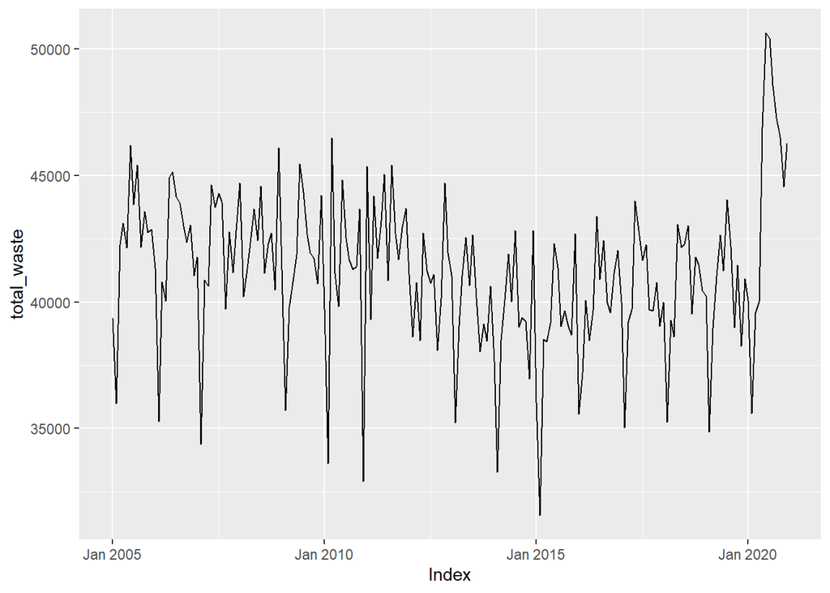

```r
DSNY_BX_zoo_ts <- ts(DSNY_third_bronx[,-1],
                     start = as.yearmon(DSNY_third_bronx$month)[1],
                     frequency = 12)

autoplot(as.zoo(DSNY_BX_zoo_ts))
```

### $\text{ARIMA(0,0,0)}$ with constant

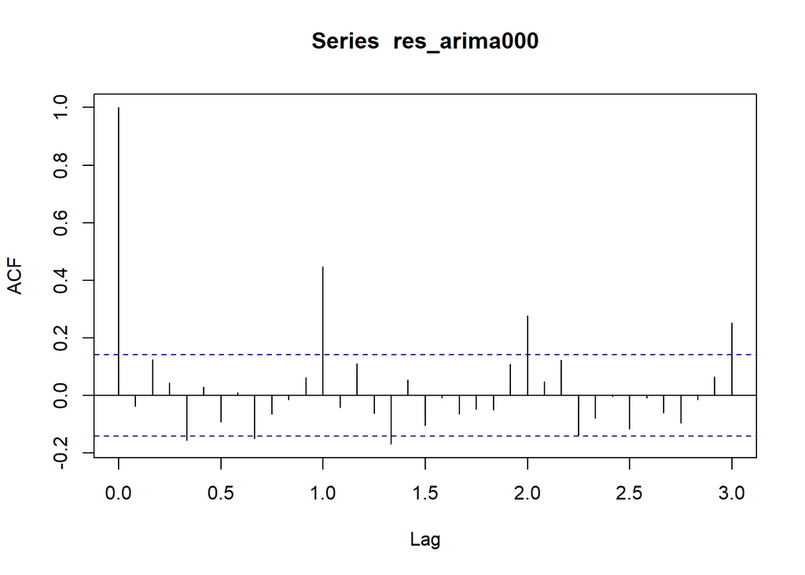

```r
zoo_arima000_fit <- arima(DSNY_BX_zoo_ts, order = 1 + c(0,0,0))
#names(zoo_arima000_fit)
res_arima000 <- zoo_arima000_fit$residuals
acf(res_arima000, lag.max = 36)
```

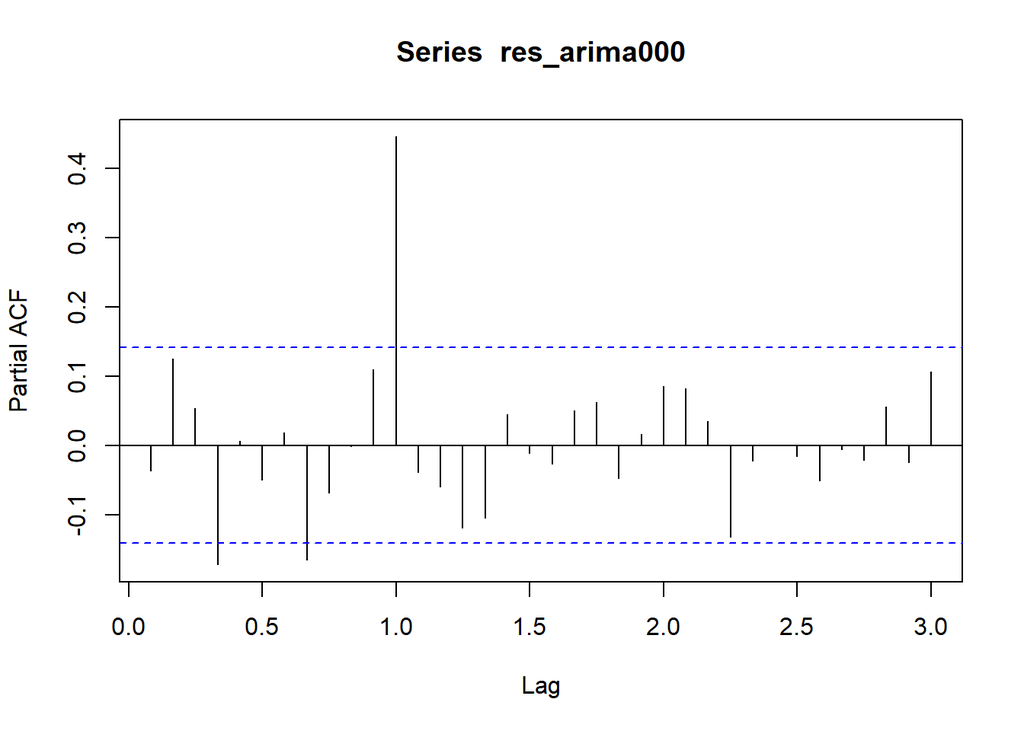

```r
pacf(res_arima000, lag.max = 36)
```

```r
accuracy(bx_arima000_fit)[4]
```

```
## # A tibble: 1 x 1
##    RMSE
##   <dbl>
## 1 2998.
```

The lags are in decimal format. With the frequency defined as 12, I believe Lag 1.0 = 12, Lag 2.0 = 24, Lag 3.0 = 36.

For ARIMA models with differencing, the differenced series follows a zero-mean ARMA model. Documentation by [DataCamp](https://www.rdocumentation.org/packages/stats/versions/3.6.2/topics/arima).

### $\text{ARIMA(0,1,0)}$ with constant/mean

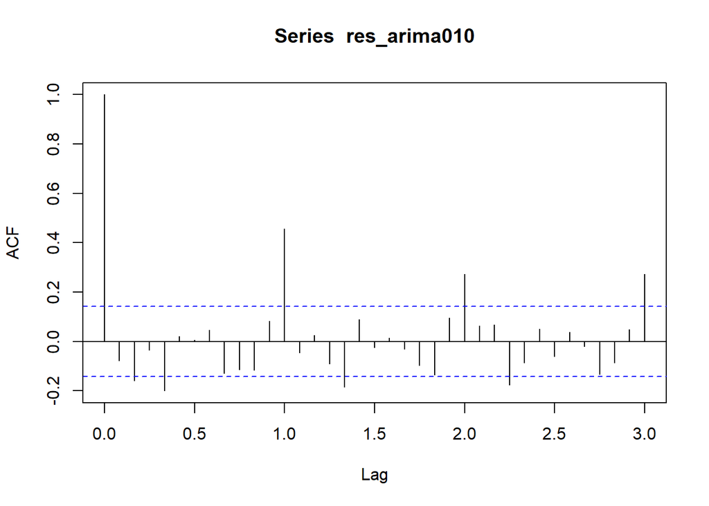

```r
zoo_arima010_fit <- arima(DSNY_BX_zoo_ts,
                          order = 1 + c(0,1,0)) #the PACF plot return the same values
                          #with or without the include.mean = parameter
res_arima010 <- zoo_arima010_fit$residuals
acf(res_arima010, lag.max = 36)
```

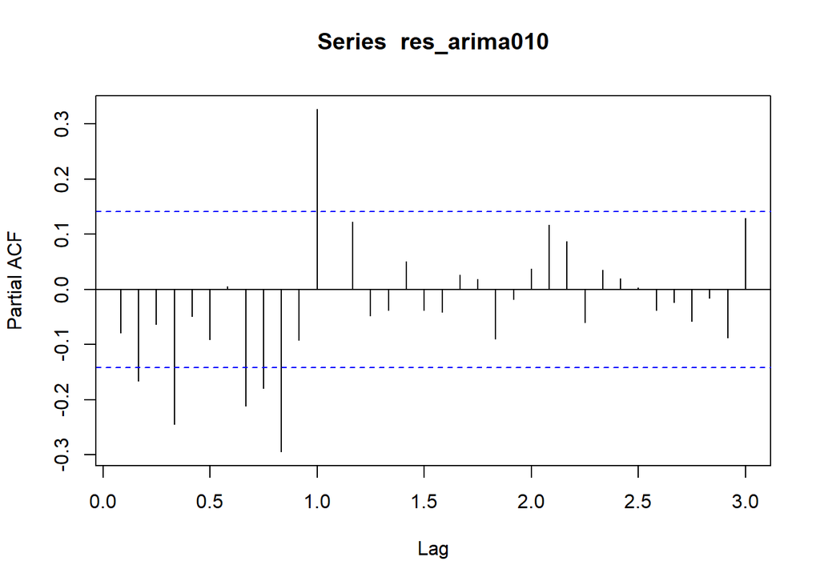

```r
pacf(res_arima010, lag.max = 36)
```

```r
accuracy(bx_arima010_fit)[4]
```

```
## # A tibble: 1 x 1
##    RMSE
##   <dbl>
## 1 3317.
```

### $\text{ARIMA(0,1,1)}$ with a constant

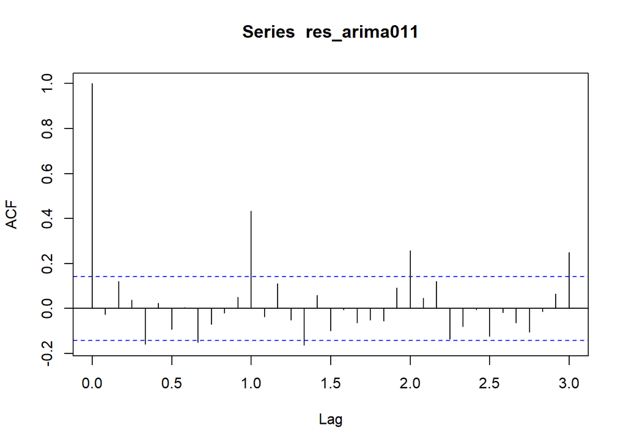

```r
bx_arima011_fit_cons <- bx_ts %>% model(arima011_constant = ARIMA(total_waste ~ 1 + pdq(0,1,1)))
zoo_arima011_fit <- arima(DSNY_BX_zoo_ts,
                          order = 1 + c(0,1,1))
res_arima011 <- zoo_arima011_fit$residuals
acf(res_arima011, lag.max = 36)
```

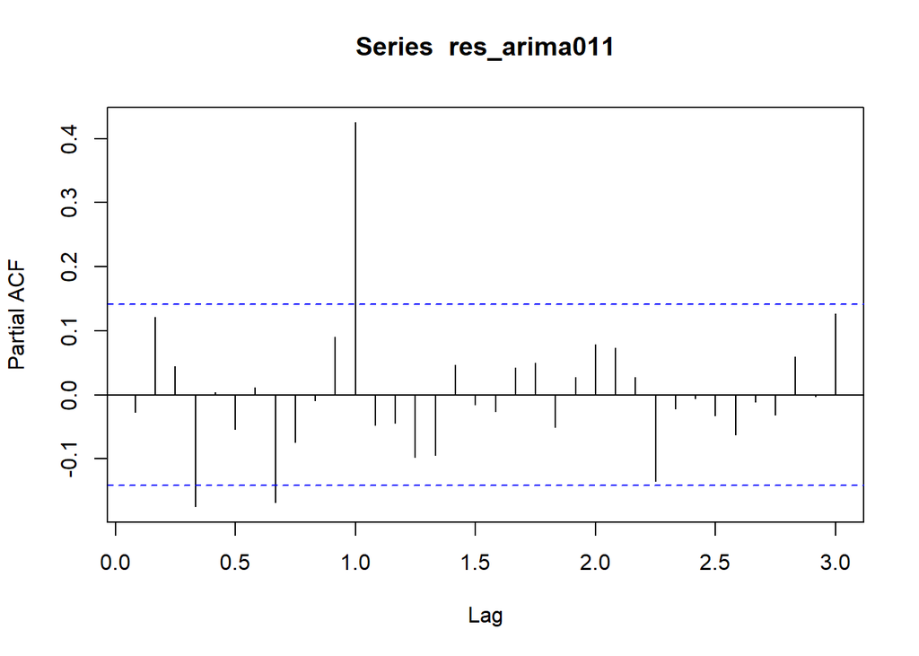

```r
pacf(res_arima011, lag.max = 36)
```

```r
accuracy(bx_arima011_fit_cons)[4]
```

```
## # A tibble: 1 x 1
##    RMSE
##   <dbl>
## 1 2818.
```

The lag one value of the ACF plot is 1.0 and positive. With a seasonal pattern of significant lags at each whole lag. There definitely should be a seasonal argument.

### $\text{ARIMA(0,1,2)}$ with a constant

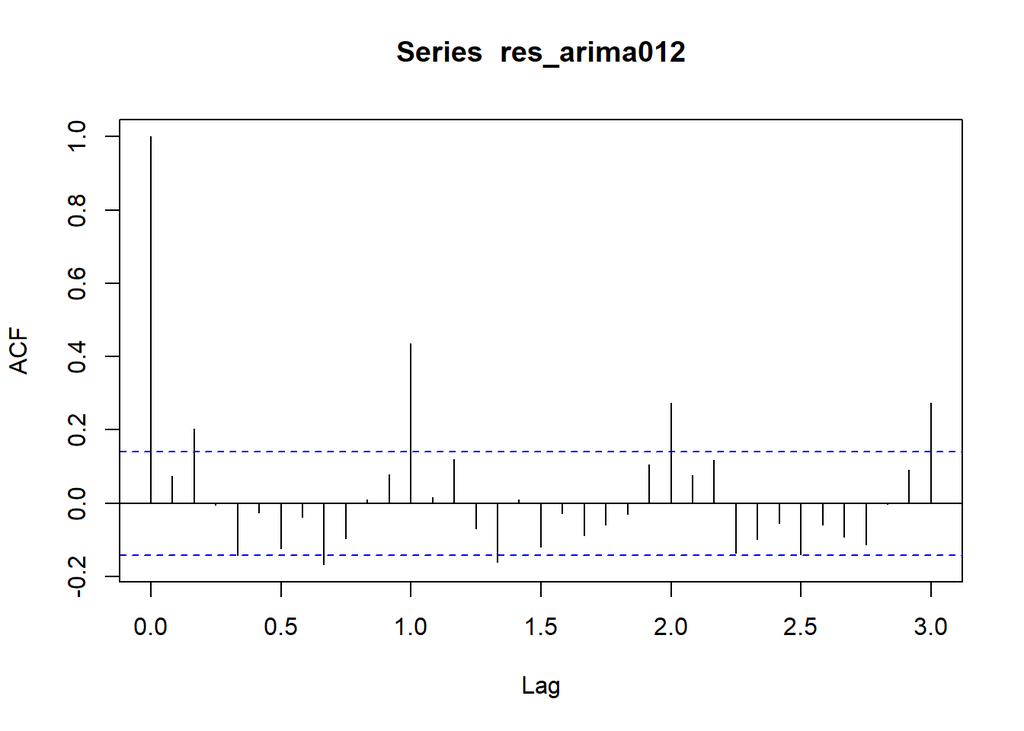

```r
bx_arima012_cons_fit <- bx_ts %>% model(arima012_cons = ARIMA(total_waste ~ 1 + pdq(0,1,2)))
zoo_arima012_fit <- arima(DSNY_BX_zoo_ts,
                          order = 1+ c(0,1,2))
res_arima012 <- zoo_arima012_fit$residuals
acf(res_arima012, lag.max = 36)
```

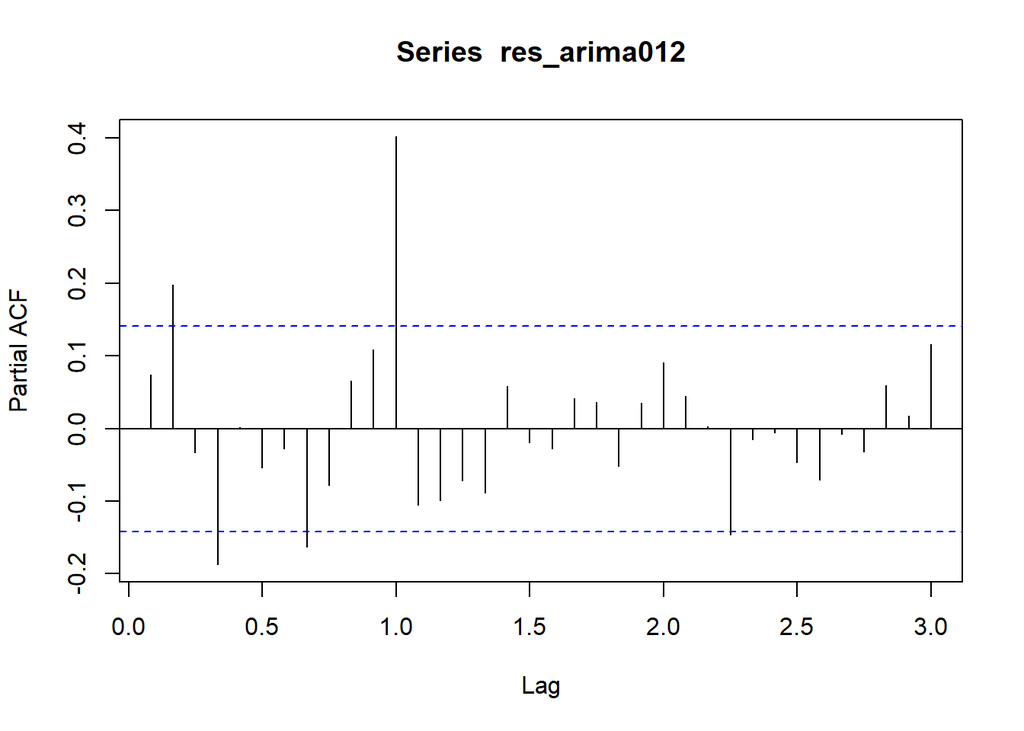

```r
pacf(res_arima012, lag.max = 36)
```

```r
accuracy(bx_arima012_cons_fit)[4]
```

```
## # A tibble: 1 x 1
##    RMSE
##   <dbl>
## 1 2765.
```

Lags (2,4,8) are significant in the PACF(). I am not sure if the lag 2 value of the PACF() is encouraging us to add an AR(2) argument. I would believe that this would remove any progress we have made. For now, attempt an MA(1) model or I think it is best to address the seasonal lags. The RMSE is the lowest so far.

### $\text{ARIMA(0,1,2)(0,0,1)}$ with a constant and seasonal period = 12

$\text{ARIMA(0,1,2)(0,0,1)}_{12}$

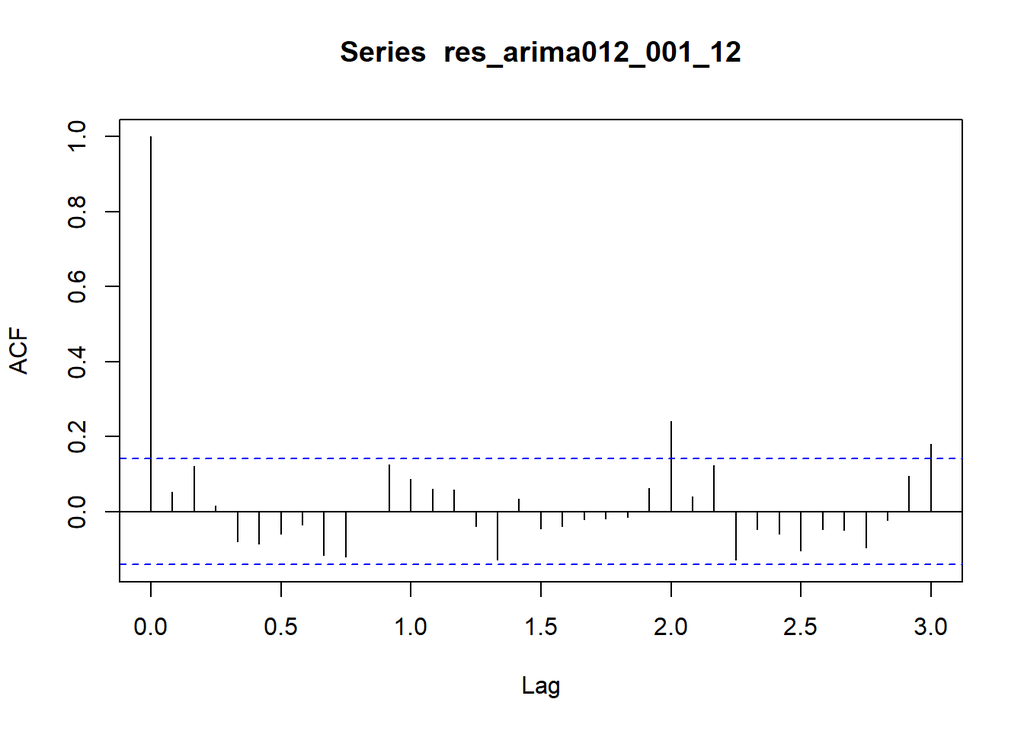

```r
bx_arima012_cons_001_12 <- bx_ts %>% model(bx_arima012_001_12 = ARIMA(total_waste ~ 1 +
                                                                   pdq(0,1,2) +
                                                                   PDQ(0,0,1, period = 12)))
zoo_arima012_001_12fit <- arima(DSNY_BX_zoo_ts,
                                order = 1 + c(0,1,2),
                                seasonal = list(order = c(0L,0L,1),
                                                period = 12))
res_arima012_001_12 <- zoo_arima012_001_12fit$residuals
acf(res_arima012_001_12, lag.max = 36)
```

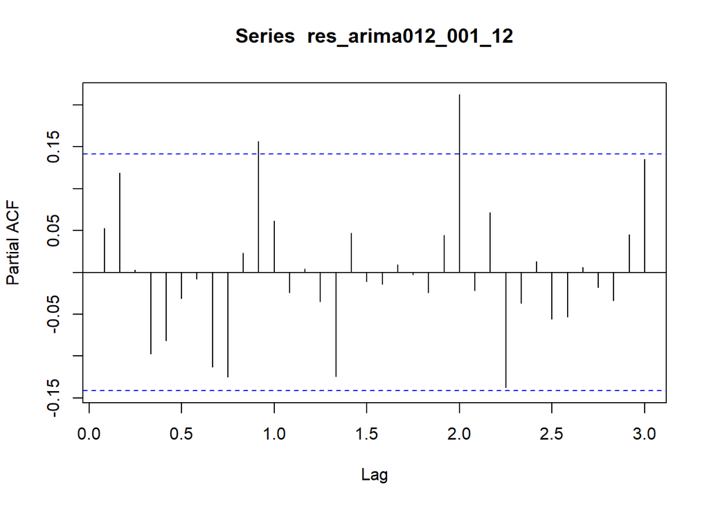

```r
pacf(res_arima012_001_12, lag.max = 36)
```

```r
accuracy(bx_arima012_cons_001_12)[4]
```

```
## # A tibble: 1 x 1
##    RMSE
##   <dbl>
## 1 2471.
```

It appears that the seasonal lags in the PACF() plot appear to still be significant. It also appears that we have bounded the PACF values between (-0.15, 0.2). The RMSE is now the lowest of them all. From meeting 6, I believe that this was the best ARIMA() fitting of them all. But I will try to reduce the MA() parameter by one.

### $\text{ARIMA(0,1,1)(0,0,1)}$ with a constant and seasonal period = 12

$\text{ARIMA(0,1,1)(0,0,1)}_{12}$

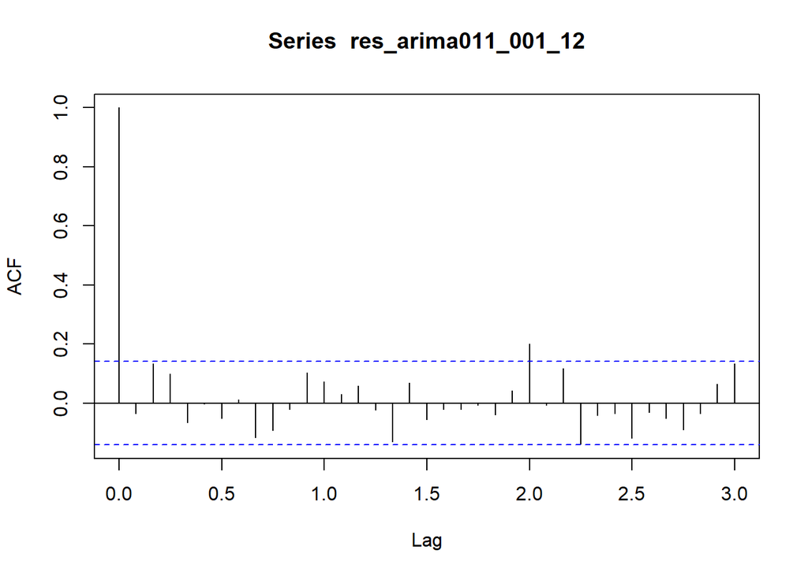

```r
bx_arima011_cons_001_12 <- bx_ts %>% model(bx_arima011_cons_001_12 = ARIMA(total_waste ~ 1 +
                                                                             pdq(0,1,1) +
                                                                             PDQ(0,0,1, period = 12)))
zoo_arima011_001_12fit <- arima(DSNY_BX_zoo_ts,
                                order = 1 + c(0,1,1),
                                seasonal = list(order = c(0L,0L,1),
                                                period = 12))
res_arima011_001_12 <- zoo_arima011_001_12fit$residuals
acf(res_arima011_001_12, lag.max = 36)
```

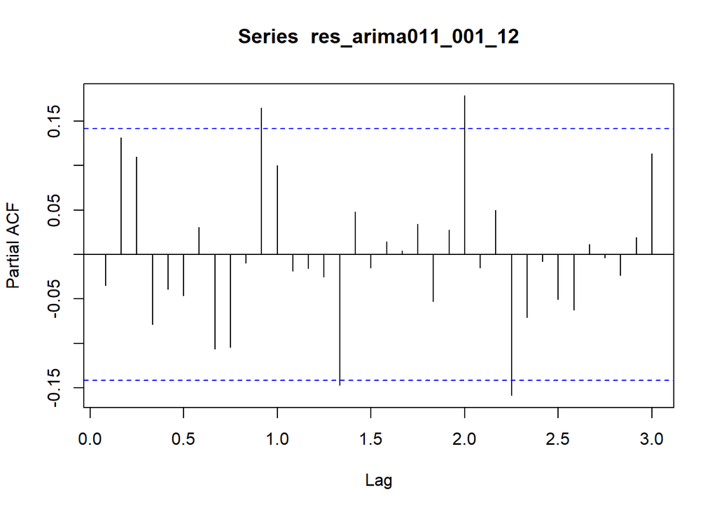

```r
pacf(res_arima011_001_12, lag.max = 36)
```

```r
accuracy(bx_arima011_cons_001_12)[4]
```

```
## # A tibble: 1 x 1
##    RMSE
##   <dbl>
## 1 2486.
```

### $\text{ARIMA(0,1,1)(1,0,0)}$ with a constant and seasonal period = 12

$\text{ARIMA(0,1,1)(1,0,0)}_{12}$

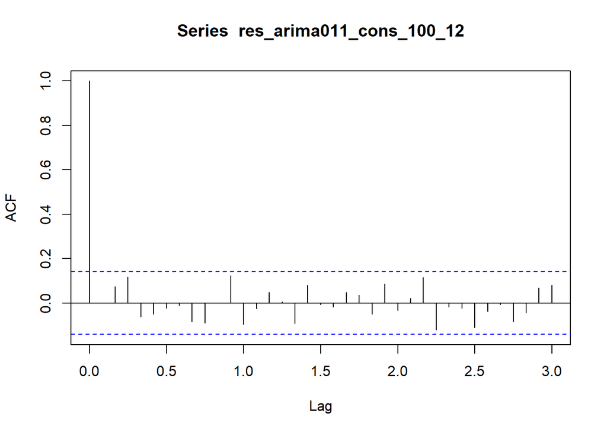

```r
bx_arima011_cons_100_12 <- bx_ts %>% model(bx_arima011_cons_100_12 = ARIMA(total_waste ~ 1 +
                                                                   pdq(0,1,1) +
                                                                   PDQ(1,0,0, period = 12)))
zoo_arima011_cons_100_12fit <- arima(DSNY_BX_zoo_ts,
                                order = 1 + c(0,1,1),
                                seasonal = list(order = c(1,0L,0L),
                                                period = 12))
res_arima011_cons_100_12 <- zoo_arima011_cons_100_12fit$residuals
acf(res_arima011_cons_100_12, lag.max = 36)
```

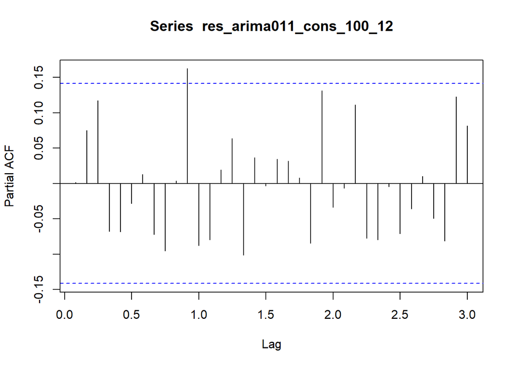

```r
pacf(res_arima011_cons_100_12, lag.max = 36)
```

```r
accuracy(bx_arima011_cons_100_12)[4]
```

```
## # A tibble: 1 x 1
##    RMSE
##   <dbl>
## 1 2341.
```

Lowest RMSE

## In conclusion

The models with the most promising ACF and PACF plots are $\text{ARIMA(0,1,1)(1,0,0)}_{12}$, and $\text{ARIMA(0,1,1)(0,0,1)}_{12}$.